# LoGRTryLong

Mohd Azmi

01/11/2019

# Pre-amble

## Library

```r
library(haven)
library(knitr)
library(tidyr)
library(psych)
library(ggplot2)
library(dplyr)
library(broom)
library(corrplot)
library(mfp)
library(generalhoslem)
library(ResourceSelection)
library(LogisticDx)
```

## Dataset

Import dataset

```r
LogDS <- read_dta("diabetes.dta")
kable(head(LogDS))
```

| codesub | age | dmdx | height | weight | waist | hip | msbpr | mdbpr | hba1c | fbs | mogtt2h | totchol | ftrigliz | hdl | ldl | gender | crural | bmi |
| --- | --- | --- | --- | --- | --- | --- | --- | --- | --- | --- | --- | --- | --- | --- | --- | --- | --- | --- |
| R-S615112 | 70 | 0 | 1.54 | 40.0 | 76.0 | 61 | 135 | 80.0 | 5.2 | 3.99 | 3.22 | 5.43 | 1.06 | 1.65 | 2.69 | 0 | 1 | 16.86625 |
| MAA615089 | 20 | 0 | 1.74 | 54.6 | 83.0 | 62 | 105 | 58.0 | 5.3 | 4.26 | 6.49 | 5.13 | 1.17 | 1.59 | 2.79 | 1 | 1 | 18.03409 |
| M-M616372 | 29 | 0 | 1.54 | 37.0 | 83.0 | 63 | 91 | 60.0 | 4.8 | 4.94 | 5.15 | 5.55 | 0.72 | 2.24 | 2.55 | 0 | 1 | 15.60128 |
| MFM615361 | 25 | 0 | 1.60 | 48.4 | 83.5 | 64 | 117 | 68.5 | 4.8 | 4.60 | 3.85 | 4.01 | 1.12 | 1.21 | 1.83 | 1 | 1 | 18.90625 |
| R-A615780 | 37 | 0 | 1.44 | 44.5 | 85.0 | 64 | 102 | 78.0 | 5.1 | 4.60 | 7.71 | 5.21 | 0.78 | 1.43 | 2.40 | 0 | 1 | 21.46026 |
| SAS615496 | 43 | 0 | 1.46 | 45.5 | 90.0 | 64 | 124 | 65.5 | 5.1 | 4.42 | 5.65 | 6.19 | 1.11 | 2.18 | 2.93 | 0 | 1 | 21.34547 |

Convert categorical data

```r
LogDS$dmdxcat <- as_factor(LogDS$dmdx)
LogDS$gendercat <- as_factor(LogDS$gender)
LogDS$cruralcat <- as_factor(LogDS$crural)
kable(head(LogDS))
```

| codesub | age | dmdx | height | weight | waist | hip | msbpr | mdbpr | hba1c | fbs | mogtt2h | totchol | ftrigliz | hdl | ldl | gender | crural | bmi | dmdxcat | gendercat | cruralcat |
| --- | --- | --- | --- | --- | --- | --- | --- | --- | --- | --- | --- | --- | --- | --- | --- | --- | --- | --- | --- | --- | --- |
| R-S615112 | 70 | 0 | 1.54 | 40.0 | 76.0 | 61 | 135 | 80.0 | 5.2 | 3.99 | 3.22 | 5.43 | 1.06 | 1.65 | 2.69 | 0 | 1 | 16.86625 | no | female | rural |
| MAA615089 | 20 | 0 | 1.74 | 54.6 | 83.0 | 62 | 105 | 58.0 | 5.3 | 4.26 | 6.49 | 5.13 | 1.17 | 1.59 | 2.79 | 1 | 1 | 18.03409 | no | male | rural |
| M-M616372 | 29 | 0 | 1.54 | 37.0 | 83.0 | 63 | 91 | 60.0 | 4.8 | 4.94 | 5.15 | 5.55 | 0.72 | 2.24 | 2.55 | 0 | 1 | 15.60128 | no | female | rural |
| MFM615361 | 25 | 0 | 1.60 | 48.4 | 83.5 | 64 | 117 | 68.5 | 4.8 | 4.60 | 3.85 | 4.01 | 1.12 | 1.21 | 1.83 | 1 | 1 | 18.90625 | no | male | rural |
| R-A615780 | 37 | 0 | 1.44 | 44.5 | 85.0 | 64 | 102 | 78.0 | 5.1 | 4.60 | 7.71 | 5.21 | 0.78 | 1.43 | 2.40 | 0 | 1 | 21.46026 | no | female | rural |
| SAS615496 | 43 | 0 | 1.46 | 45.5 | 90.0 | 64 | 124 | 65.5 | 5.1 | 4.42 | 5.65 | 6.19 | 1.11 | 2.18 | 2.93 | 0 | 1 | 21.34547 | no | female | rural |

alternatively, dplyr::mutate can also be use

```r
LogDS2 <- LogDS %>%
  mutate (dmdxcat = as_factor(dmdx),
          gendercat = as_factor(gender),
          cruralcat = as_factor(crural))
kable(head(LogDS2))
```

| codesub | age | dmdx | height | weight | waist | hip | msbpr | mdbpr | hba1c | fbs | mogtt2h | totchol | ftrigliz | hdl | ldl | gender | crural | bmi | dmdxcat | gendercat | cruralcat |
| --- | --- | --- | --- | --- | --- | --- | --- | --- | --- | --- | --- | --- | --- | --- | --- | --- | --- | --- | --- | --- | --- |
| R-S615112 | 70 | 0 | 1.54 | 40.0 | 76.0 | 61 | 135 | 80.0 | 5.2 | 3.99 | 3.22 | 5.43 | 1.06 | 1.65 | 2.69 | 0 | 1 | 16.86625 | no | female | rural |
| MAA615089 | 20 | 0 | 1.74 | 54.6 | 83.0 | 62 | 105 | 58.0 | 5.3 | 4.26 | 6.49 | 5.13 | 1.17 | 1.59 | 2.79 | 1 | 1 | 18.03409 | no | male | rural |
| M-M616372 | 29 | 0 | 1.54 | 37.0 | 83.0 | 63 | 91 | 60.0 | 4.8 | 4.94 | 5.15 | 5.55 | 0.72 | 2.24 | 2.55 | 0 | 1 | 15.60128 | no | female | rural |
| MFM615361 | 25 | 0 | 1.60 | 48.4 | 83.5 | 64 | 117 | 68.5 | 4.8 | 4.60 | 3.85 | 4.01 | 1.12 | 1.21 | 1.83 | 1 | 1 | 18.90625 | no | male | rural |
| R-A615780 | 37 | 0 | 1.44 | 44.5 | 85.0 | 64 | 102 | 78.0 | 5.1 | 4.60 | 7.71 | 5.21 | 0.78 | 1.43 | 2.40 | 0 | 1 | 21.46026 | no | female | rural |
| SAS615496 | 43 | 0 | 1.46 | 45.5 | 90.0 | 64 | 124 | 65.5 | 5.1 | 4.42 | 5.65 | 6.19 | 1.11 | 2.18 | 2.93 | 0 | 1 | 21.34547 | no | female | rural |

# Data Exploration

## Data summary

```r
kable(summary(LogDS [, 20:22]))
```

|  | dmdxcat | gendercat | cruralcat |
| --- | --- | --- | --- |
|  | no :3363 | female:2497 | urban:2001 |
|  | yes: 457 | male :1323 | rural:1819 |

```r
summary(LogDS)
```

```
##    codesub               age             dmdx            height
##  Length:3820        Min.   :18.00   Min.   :0.0000   Min.   :1.290
##  Class :character   1st Qu.:38.00   1st Qu.:0.0000   1st Qu.:1.510
##  Mode  :character   Median :48.00   Median :0.0000   Median :1.560
##                     Mean   :47.92   Mean   :0.1196   Mean   :1.568
##                     3rd Qu.:58.00   3rd Qu.:0.0000   3rd Qu.:1.630
##                     Max.   :89.00   Max.   :1.0000   Max.   :1.960
##
##      weight           waist             hip             msbpr
##  Min.   : 30.00   Min.   : 50.80   Min.   : 61.00   Min.   : 76.5
##  1st Qu.: 53.60   1st Qu.: 77.00   1st Qu.: 91.00   1st Qu.:117.0
##  Median : 62.00   Median : 86.00   Median : 97.00   Median :129.8
##  Mean   : 63.25   Mean   : 85.92   Mean   : 97.51   Mean   :132.7
##  3rd Qu.: 71.50   3rd Qu.: 94.40   3rd Qu.:104.00   3rd Qu.:146.0
##  Max.   :128.50   Max.   :134.00   Max.   :148.00   Max.   :210.0
##                   NA's   :2        NA's   :2
##      mdbpr            hba1c             fbs            mogtt2h
##  Min.   : 41.50   Min.   : 3.800   Min.   : 2.500   Min.   : 0.170
##  1st Qu.: 70.00   1st Qu.: 5.100   1st Qu.: 4.460   1st Qu.: 5.210
##  Median : 77.50   Median : 5.400   Median : 5.160   Median : 6.610
##  Mean   : 77.98   Mean   : 5.782   Mean   : 5.612   Mean   : 7.206
##  3rd Qu.: 85.12   3rd Qu.: 5.800   3rd Qu.: 5.960   3rd Qu.: 8.350
##  Max.   :123.00   Max.   :15.000   Max.   :28.010   Max.   :29.830
##                                    NA's   :3        NA's   :420
##     totchol         ftrigliz          hdl             ldl
##  Min.   : 2.13   Min.   :0.180   Min.   :0.120   Min.   :0.510
##  1st Qu.: 4.96   1st Qu.:0.920   1st Qu.:1.110   1st Qu.:2.800
##  Median : 5.70   Median :1.250   Median :1.330   Median :3.460
##  Mean   : 5.77   Mean   :1.511   Mean   :1.355   Mean   :3.543
##  3rd Qu.: 6.50   3rd Qu.:1.752   3rd Qu.:1.550   3rd Qu.:4.220
##  Max.   :14.91   Max.   :7.990   Max.   :4.430   Max.   :9.420
##
##      gender           crural            bmi         dmdxcat
##  Min.   :0.0000   Min.   :0.0000   Min.   : 9.241   no :3363
##  1st Qu.:0.0000   1st Qu.:0.0000   1st Qu.:22.176   yes: 457
##  Median :0.0000   Median :0.0000   Median :25.283
##  Mean   :0.3463   Mean   :0.4762   Mean   :25.688
##  3rd Qu.:1.0000   3rd Qu.:1.0000   3rd Qu.:28.674
##  Max.   :1.0000   Max.   :1.0000   Max.   :42.374
##
##   gendercat    cruralcat
##  female:2497   urban:2001
##  male  :1323   rural:1819
##
##
##
##
##
```

```r
kable(describe(LogDS [, c(2, 4:10, 12)]))
```

[output not shown]

Histogram for numerical data

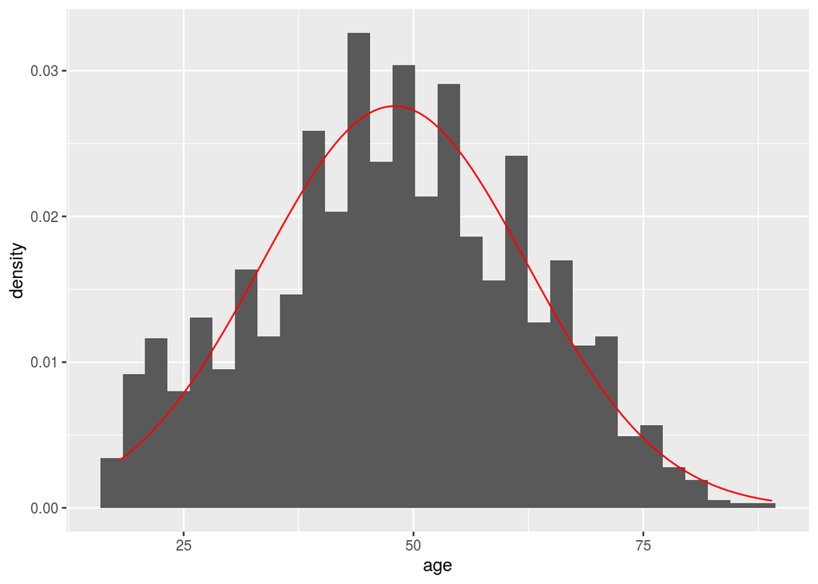

```r
ggplot(LogDS, aes(age)) +
  geom_histogram(aes(y=..density..)) +
  stat_function(fun = dnorm, colour = "red",
                args = list(mean = mean(LogDS$age),
                            sd = sd(LogDS$age)))
```

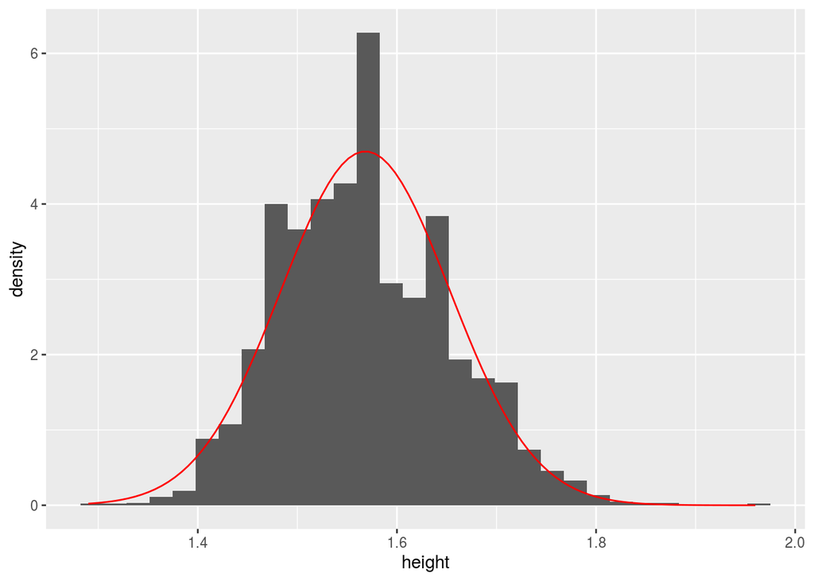

```r
ggplot(LogDS, aes(height)) +
  geom_histogram(aes(y=..density..)) +
  stat_function(fun = dnorm, colour = "red",
                args = list(mean = mean(LogDS$height),
                            sd = sd(LogDS$height)))
```

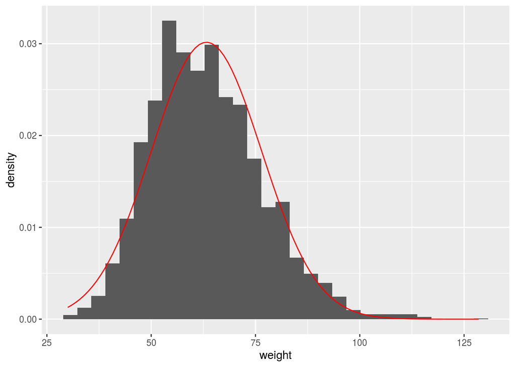

```r
ggplot(LogDS, aes(weight)) +
  geom_histogram(aes(y=..density..)) +
  stat_function(fun = dnorm, colour = "red",
                args = list(mean = mean(LogDS$weight),
                            sd = sd(LogDS$weight)))
```

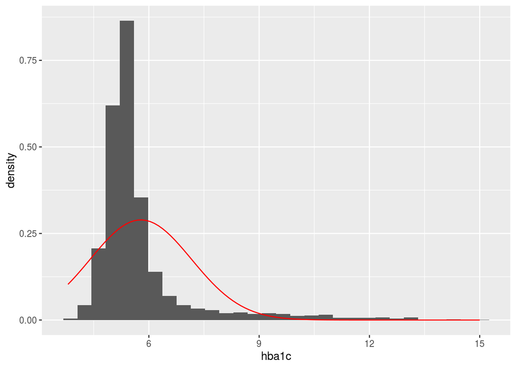

```r
ggplot(LogDS, aes(hba1c)) +
  geom_histogram(aes(y=..density..)) +
  stat_function(fun = dnorm, colour = "red",
                args = list(mean = mean(LogDS$hba1c),
                            sd = sd(LogDS$hba1c)))
```

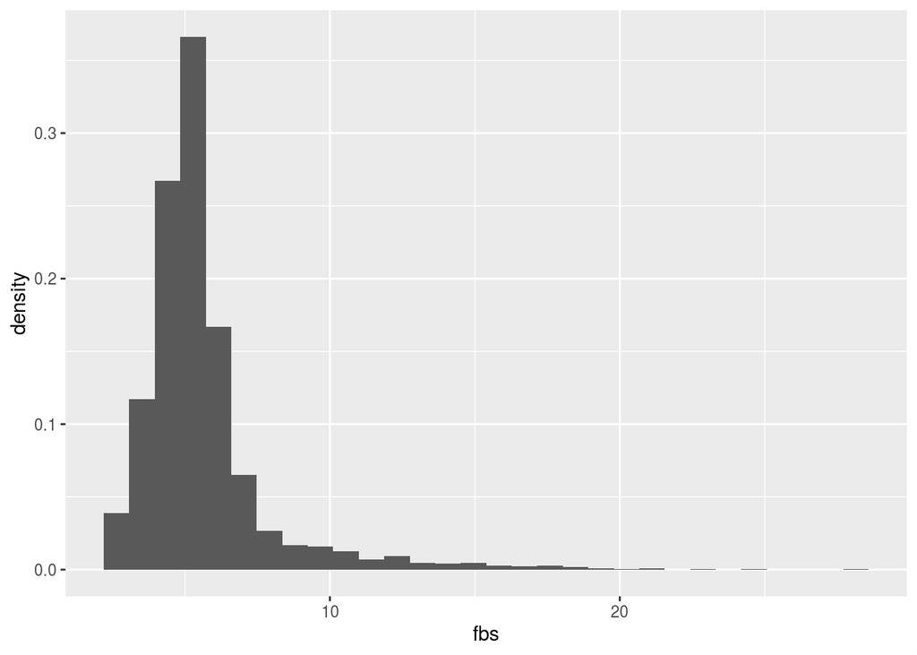

```r
ggplot(LogDS, aes(fbs)) +
  geom_histogram(aes(y=..density..)) +
  stat_function(fun = dnorm, colour = "red",
                args = list(mean = mean(LogDS$fbs),
                            sd = sd(LogDS$fbs)))
```

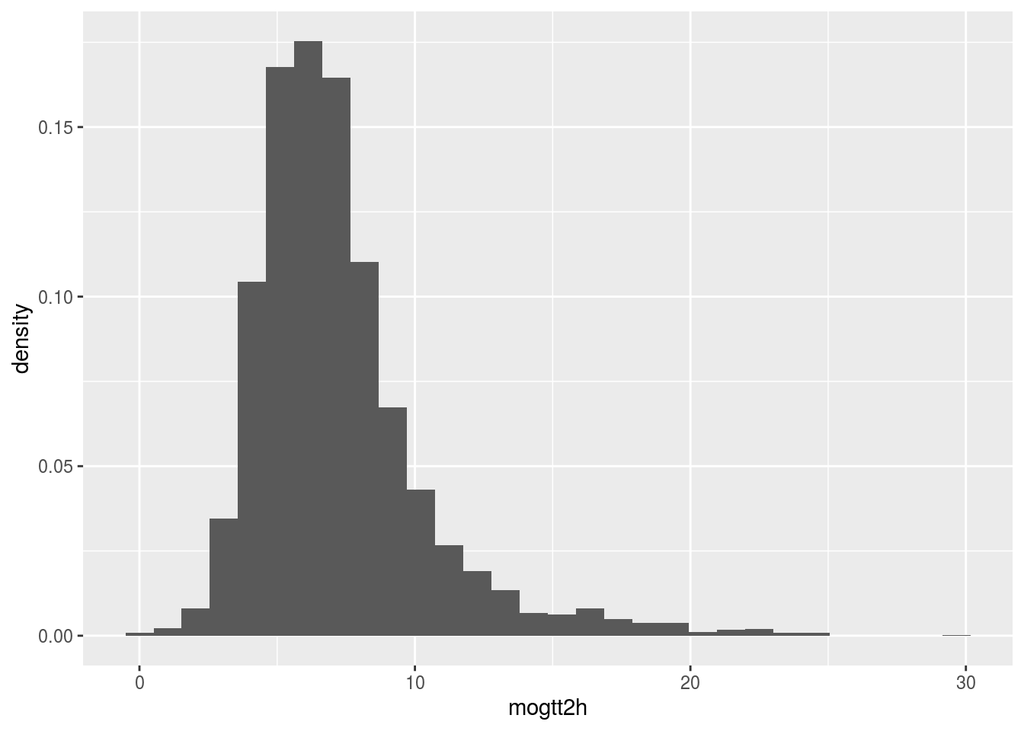

```r
ggplot(LogDS, aes(mogtt2h)) +
  geom_histogram(aes(y=..density..)) +
  stat_function(fun = dnorm, colour = "red",
                args = list(mean = mean(LogDS$mogtt2h),
                            sd = sd(LogDS$mogtt2h)))
```

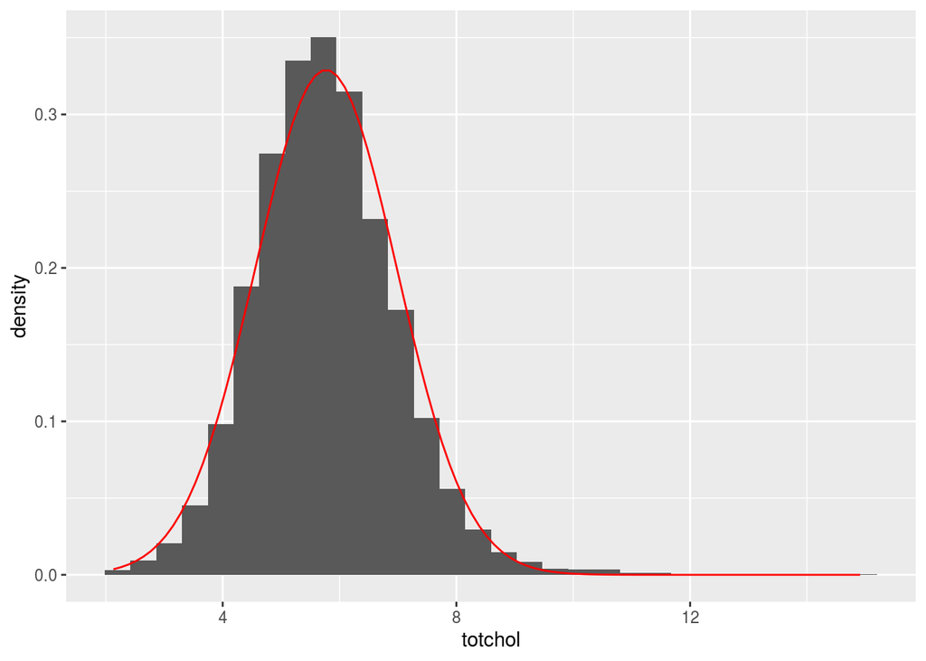

```r
ggplot(LogDS, aes(totchol)) +
  geom_histogram(aes(y=..density..)) +
  stat_function(fun = dnorm, colour = "red",
                args = list(mean = mean(LogDS$totchol),
                            sd = sd(LogDS$totchol)))
```

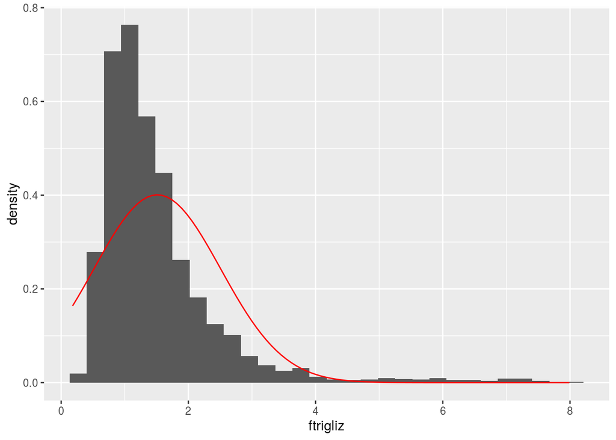

```r
ggplot(LogDS, aes(ftrigliz)) +
  geom_histogram(aes(y=..density..)) +
  stat_function(fun = dnorm, colour = "red",
                args = list(mean = mean(LogDS$ftrigliz),
                            sd = sd(LogDS$ftrigliz)))
```

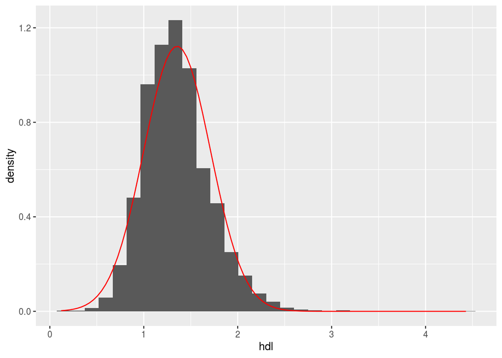

```r
ggplot(LogDS, aes(hdl)) +
  geom_histogram(aes(y=..density..)) +
  stat_function(fun = dnorm, colour = "red",
                args = list(mean = mean(LogDS$hdl),
                            sd = sd(LogDS$hdl)))
```

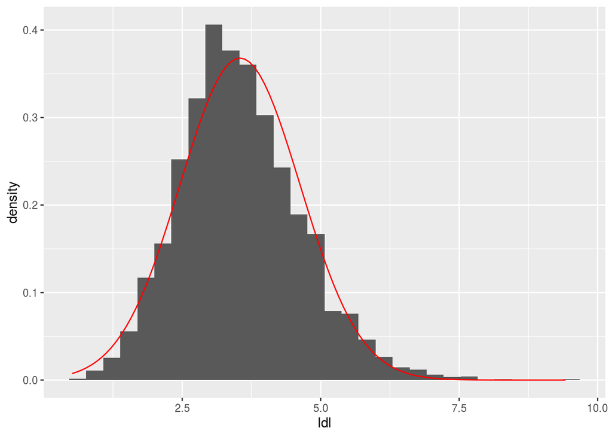

```r
ggplot(LogDS, aes(ldl)) +
  geom_histogram(aes(y=..density..)) +
  stat_function(fun = dnorm, colour = "red",
                args = list(mean = mean(LogDS$ldl),
                            sd = sd(LogDS$ldl)))
```

Bar chart for categorical data

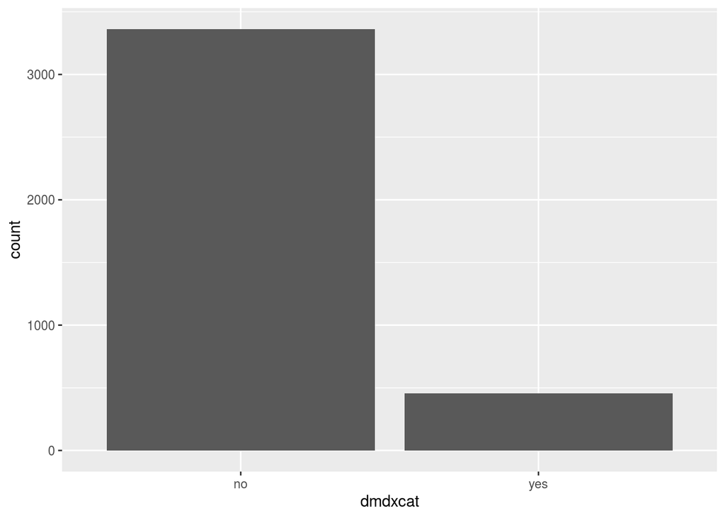

```r
ggplot(LogDS, aes(dmdxcat)) +
  geom_bar()
```

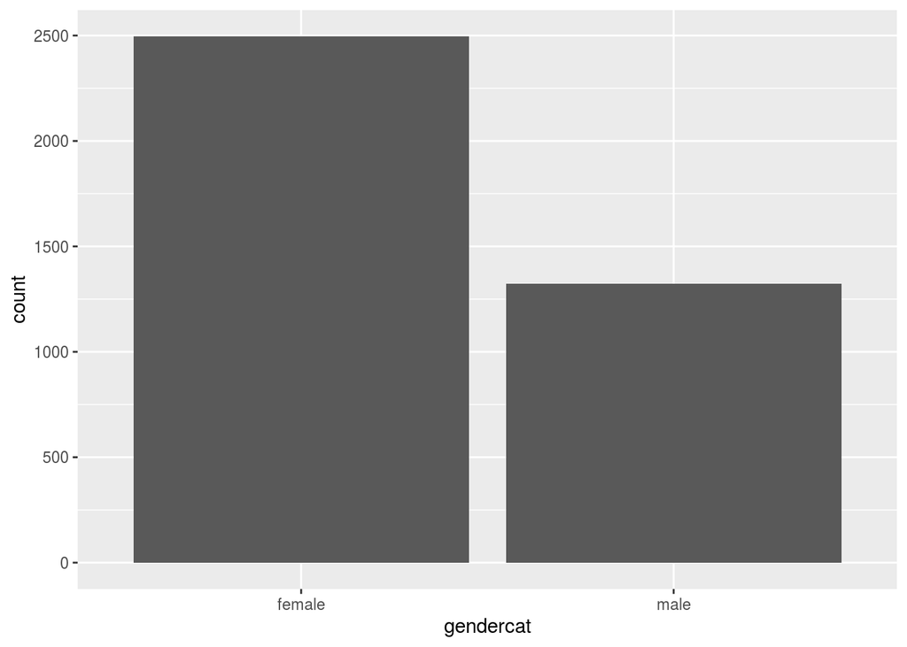

```r
ggplot(LogDS, aes(gendercat)) +
  geom_bar()
```

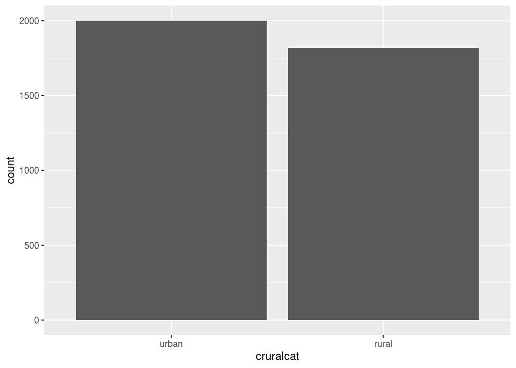

```r
ggplot(LogDS, aes(cruralcat)) +
  geom_bar()
```

Correlation Matrix among Numerical Data

```r
LogDS_Num <- LogDS %>%
  select_if(is.numeric)
Cor_LogDS_Num <- cor(LogDS_Num, use = "complete.obs", method = "pearson")
kable(round(Cor_LogDS_Num,2))
```

|  | age | dmdx | height | weight | waist | hip | msbpr | mdbpr | hba1c | fbs | mogtt2h | totchol | ftrigliz | hdl | ldl | gender | crural | bmi |
| --- | --- | --- | --- | --- | --- | --- | --- | --- | --- | --- | --- | --- | --- | --- | --- | --- | --- | --- |
| age | 1.00 | 0.02 | -0.21 | -0.07 | 0.14 | 0.01 | 0.46 | 0.23 | 0.18 | 0.20 | 0.23 | 0.32 | 0.13 | 0.16 | 0.26 | 0.02 | 0.04 | 0.04 |
| dmdx | 0.02 | 1.00 | -0.01 | 0.03 | 0.02 | 0.02 | 0.03 | 0.03 | 0.12 | 0.10 | 0.11 | 0.01 | 0.00 | 0.00 | 0.00 | 0.00 | -0.03 | 0.03 |
| height | -0.21 | -0.01 | 1.00 | 0.43 | 0.15 | 0.12 | -0.06 | 0.00 | -0.03 | -0.04 | -0.15 | -0.07 | 0.07 | -0.18 | -0.05 | 0.67 | -0.09 | -0.09 |
| weight | -0.07 | 0.03 | 0.43 | 1.00 | 0.78 | 0.78 | 0.18 | 0.28 | 0.17 | 0.13 | 0.15 | 0.05 | 0.22 | -0.23 | 0.12 | 0.27 | -0.07 | 0.85 |
| waist | 0.14 | 0.02 | 0.15 | 0.78 | 1.00 | 0.58 | 0.27 | 0.29 | 0.23 | 0.16 | 0.23 | 0.12 | 0.22 | -0.21 | 0.14 | 0.12 | 0.05 | 0.77 |
| hip | 0.01 | 0.02 | 0.12 | 0.78 | 0.58 | 1.00 | 0.15 | 0.23 | 0.15 | 0.14 | 0.19 | 0.08 | 0.18 | -0.13 | 0.16 | -0.04 | -0.13 | 0.80 |
| msbpr | 0.46 | 0.03 | -0.06 | 0.18 | 0.27 | 0.15 | 1.00 | 0.71 | 0.17 | 0.19 | 0.25 | 0.23 | 0.20 | 0.00 | 0.20 | 0.09 | 0.12 | 0.23 |
| mdbpr | 0.23 | 0.03 | 0.00 | 0.28 | 0.29 | 0.23 | 0.71 | 1.00 | 0.16 | 0.12 | 0.23 | 0.17 | 0.20 | -0.07 | 0.16 | 0.08 | 0.05 | 0.31 |
| hba1c | 0.18 | 0.12 | -0.03 | 0.17 | 0.23 | 0.15 | 0.17 | 0.16 | 1.00 | 0.47 | 0.54 | 0.17 | 0.18 | 0.01 | 0.16 | 0.00 | 0.04 | 0.20 |
| fbs | 0.20 | 0.10 | -0.04 | 0.13 | 0.16 | 0.14 | 0.19 | 0.12 | 0.47 | 1.00 | 0.58 | 0.15 | 0.20 | 0.03 | 0.14 | 0.01 | 0.02 | 0.17 |
| mogtt2h | 0.23 | 0.11 | -0.15 | 0.15 | 0.23 | 0.19 | 0.25 | 0.23 | 0.54 | 0.58 | 1.00 | 0.18 | 0.22 | 0.02 | 0.20 | -0.12 | -0.02 | 0.26 |
| totchol | 0.32 | 0.01 | -0.07 | 0.05 | 0.12 | 0.08 | 0.23 | 0.17 | 0.17 | 0.15 | 0.18 | 1.00 | 0.26 | 0.30 | 0.76 | 0.01 | 0.10 | 0.10 |
| ftrigliz | 0.13 | 0.00 | 0.07 | 0.22 | 0.22 | 0.18 | 0.20 | 0.20 | 0.18 | 0.20 | 0.22 | 0.26 | 1.00 | -0.20 | 0.15 | 0.13 | 0.09 | 0.20 |
| hdl | 0.16 | 0.00 | -0.18 | -0.23 | -0.21 | -0.13 | 0.00 | -0.07 | 0.01 | 0.03 | 0.02 | 0.30 | -0.20 | 1.00 | 0.25 | -0.24 | -0.04 | -0.15 |
| ldl | 0.26 | 0.00 | -0.05 | 0.12 | 0.14 | 0.16 | 0.20 | 0.16 | 0.16 | 0.14 | 0.20 | 0.76 | 0.15 | 0.25 | 1.00 | 0.01 | 0.05 | 0.16 |
| gender | 0.02 | 0.00 | 0.67 | 0.27 | 0.12 | -0.04 | 0.09 | 0.08 | 0.00 | 0.01 | -0.12 | 0.01 | 0.13 | -0.24 | 0.01 | 1.00 | 0.03 | -0.09 |
| crural | 0.04 | -0.03 | -0.09 | -0.07 | 0.05 | -0.13 | 0.12 | 0.05 | 0.04 | 0.02 | -0.02 | 0.10 | 0.09 | -0.04 | 0.05 | 0.03 | 1.00 | -0.02 |
| bmi | 0.04 | 0.03 | -0.09 | 0.85 | 0.77 | 0.80 | 0.23 | 0.31 | 0.20 | 0.17 | 0.26 | 0.10 | 0.20 | -0.15 | 0.16 | -0.09 | -0.02 | 1.00 |

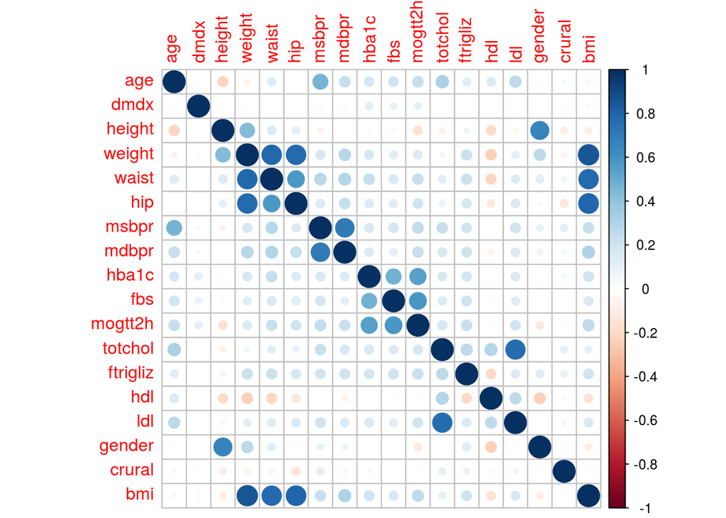

```r
corrplot(Cor_LogDS_Num)
```

# Logistic Regression Modelling

## Univariable - Simple Logistic Regression

### Model01 - age

Model01

- outcome: dmstatus
- predictor - age

```r
Model01 <- glm(dmdxcat ~ age,
               data = LogDS,
               family = binomial (link = "logit"))
summary(Model01)
```

```
##
## Call:
## glm(formula = dmdxcat ~ age, family = binomial(link = "logit"),
##     data = LogDS)
##
## Deviance Residuals:
##     Min       1Q   Median       3Q      Max
## -1.1379  -0.5451  -0.4180  -0.2955   2.6637
##
## Coefficients:
##              Estimate Std. Error z value Pr(>|z|)
## (Intercept) -4.642893   0.219626  -21.14   <2e-16 ***
## age          0.051116   0.003863   13.23   <2e-16 ***
## ---
## Signif. codes:  0 '***' 0.001 '**' 0.01 '*' 0.05 '.' 0.1 ' ' 1
##
## (Dispersion parameter for binomial family taken to be 1)
##
##     Null deviance: 2797.7  on 3819  degrees of freedom
## Residual deviance: 2602.0  on 3818  degrees of freedom
## AIC: 2606
##
## Number of Fisher Scoring iterations: 5
```

```r
kable(tidy(Model01))
```

| term | estimate | std.error | statistic | p.value |
| --- | --- | --- | --- | --- |
| (Intercept) | -4.6428926 | 0.2196262 | -21.13998 | 0 |
| age | 0.0511159 | 0.0038629 | 13.23237 | 0 |

```r
names(Model01)
```

```
##  [1] "coefficients"      "residuals"         "fitted.values"
##  [4] "effects"           "R"                 "rank"
##  [7] "qr"                "family"            "linear.predictors"
## [10] "deviance"          "aic"               "null.deviance"
## [13] "iter"              "weights"           "prior.weights"
## [16] "df.residual"       "df.null"           "y"
## [19] "converged"         "boundary"          "model"
## [22] "call"              "formula"           "terms"
## [25] "data"              "offset"            "control"
## [28] "method"            "contrasts"         "xlevels"
```

### Model02 - Gender

Model02

- outcome: dm status
- predictor - gender

```r
Model02 <- glm(dmdxcat ~ gender,
               data = LogDS,
               family = binomial (link = "logit"))
summary(Model02)
```

```
##
## Call:
## glm(formula = dmdxcat ~ gender, family = binomial(link = "logit"),
##     data = LogDS)
##
## Deviance Residuals:
##     Min       1Q   Median       3Q      Max
## -0.5392  -0.5392  -0.4859  -0.4859   2.0953
##
## Coefficients:
##             Estimate Std. Error z value Pr(>|z|)
## (Intercept) -2.07719    0.06362 -32.650   <2e-16 ***
## gender       0.22229    0.10251   2.168   0.0301 *
## ---
## Signif. codes:  0 '***' 0.001 '**' 0.01 '*' 0.05 '.' 0.1 ' ' 1
##
## (Dispersion parameter for binomial family taken to be 1)
##
##     Null deviance: 2797.7  on 3819  degrees of freedom
## Residual deviance: 2793.1  on 3818  degrees of freedom
## AIC: 2797.1
##
## Number of Fisher Scoring iterations: 4
```

```r
kable(tidy(Model02))
```

| term | estimate | std.error | statistic | p.value |
| --- | --- | --- | --- | --- |
| (Intercept) | -2.0771908 | 0.0636206 | -32.649639 | 0.0000000 |
| gender | 0.2222904 | 0.1025100 | 2.168476 | 0.0301225 |

## Multivariable - Multiple Logistic Regression

### Model11 - age & gender

Model11

- outcome: dm
- predictor: age, gender

```r
Model11 <- glm(dmdxcat ~ age + gendercat,
               family = binomial(link = "logit"),
               data = LogDS)
summary(Model11)
```

```
##
## Call:
## glm(formula = dmdxcat ~ age + gendercat, family = binomial(link = "logit"),
##     data = LogDS)
##
## Deviance Residuals:
##     Min       1Q   Median       3Q      Max
## -1.1116  -0.5453  -0.4190  -0.2970   2.6278
##
## Coefficients:
##                Estimate Std. Error z value Pr(>|z|)
## (Intercept)   -4.671495   0.220615 -21.175   <2e-16 ***
## age            0.050726   0.003867  13.117   <2e-16 ***
## gendercatmale  0.135135   0.105856   1.277    0.202
## ---
## Signif. codes:  0 '***' 0.001 '**' 0.01 '*' 0.05 '.' 0.1 ' ' 1
##
## (Dispersion parameter for binomial family taken to be 1)
##
##     Null deviance: 2797.7  on 3819  degrees of freedom
## Residual deviance: 2600.4  on 3817  degrees of freedom
## AIC: 2606.4
##
## Number of Fisher Scoring iterations: 5
```

```r
kable(tidy(Model11))
```

| term | estimate | std.error | statistic | p.value |
| --- | --- | --- | --- | --- |
| (Intercept) | -4.6714946 | 0.2206152 | -21.174850 | 0.0000000 |
| age | 0.0507257 | 0.0038672 | 13.116915 | 0.0000000 |
| gendercatmale | 0.1351354 | 0.1058564 | 1.276592 | 0.2017465 |

Calculate OR and 95% CI

```r
Table_Model11 <- tidy(Model11)
OR_Model11 <- exp(coefficients(Model11))
ORCI_Model11 <- exp(confint(Model11))
kable(cbind(Table_Model11 [, 1:5], OR_Model11, ORCI_Model11))
```

|  | term | estimate | std.error | statistic | p.value | OR_Model11 | 2.5 % | 97.5 % |
| --- | --- | --- | --- | --- | --- | --- | --- | --- |
| (Intercept) | (Intercept) | -4.6714946 | 0.2206152 | -21.174850 | 0.0000000 | 0.0093583 | 0.0060275 | 0.0143167 |
| age | age | 0.0507257 | 0.0038672 | 13.116915 | 0.0000000 | 1.0520343 | 1.0441696 | 1.0601249 |
| gendercatmale | gendercatmale | 0.1351354 | 0.1058564 | 1.276592 | 0.2017465 | 1.1446918 | 0.9290441 | 1.4071688 |

## Inference - MLE method (Wald Test)

### Wald Test for Age

$W = \beta/SE_\beta$

Example 1, calculate Wald test for Model01 (age)

```r
0.0511159/0.0038629
```

```
## [1] 13.23252
```

p-value for above.

```r
2*pnorm(-abs(0.0511159/0.0038629))
```

```
## [1] 5.694585e-40
```

### Wald Test for Gender

Wald Test for Model02 (gender)

```r
0.2222904/0.1025100
```

```
## [1] 2.168475
```

p-value for above

```r
2*pnorm(-abs(0.2222904/0.1025100))
```

```
## [1] 0.03012254
```

## Inference - SE method (Confident Interval)

### CI for Age

CI for Model01

```r
kable(tidy(confint(Model01)))
```

| .rownames | X2.5.. | X97.5.. |
| --- | --- | --- |
| (Intercept) | -5.0809899 | -4.2197791 |
| age | 0.0436191 | 0.0587673 |

the confident interval didn’t cross 1

## Inference - Likelihood Ratio Test

### LR Test fot Model01 with Model11

- Model01 - age as covariate
- Model11 - age and gender as covariate

to explore LR when gender is added to Model01

```r
anova(Model11, Model01, test="Chisq")
```

```
## Analysis of Deviance Table
##
## Model 1: dmdxcat ~ age + gendercat
## Model 2: dmdxcat ~ age
##   Resid. Df Resid. Dev Df Deviance Pr(>Chi)
## 1      3817     2600.4
## 2      3818     2602.0 -1  -1.6174   0.2035
```

### LR Test fot Model02 with Model11

- Model02 - gender as covariate
- Model11 - age and gender as covariate

to explore LR when age is added to Mofrl02

```r
anova(Model11, Model02, test="Chisq")
```

```
## Analysis of Deviance Table
##
## Model 1: dmdxcat ~ age + gendercat
## Model 2: dmdxcat ~ gender
##   Resid. Df Resid. Dev Df Deviance  Pr(>Chi)
## 1      3817     2600.4
## 2      3818     2793.1 -1  -192.68 < 2.2e-16 ***
## ---
## Signif. codes:  0 '***' 0.001 '**' 0.01 '*' 0.05 '.' 0.1 ' ' 1
```

## Model Selection

### Explore Univariable

```r
SLogMod_AgeBPSugar <- LogDS %>%
  dplyr::select(age, msbpr, mdbpr, fbs, mogtt2h, hdl) %>%
  purrr::map(~glm(dmdxcat ~ .x,
                  family = binomial,
                  data = LogDS)) %>%
  purrr::map(tidy) %>%
  bind_rows()
ResultSLogMod01 <- SLogMod_AgeBPSugar %>%
  mutate(model = c("b0", "age",
                   "b0", "msbpr",
                   "b0", "mdbpr",
                   "b0", "fbs",
                   "b0", "mogtt2h",
                   "b0", "hdl")) %>%
  dplyr::select(model, everything())
kable(ResultSLogMod01)
```

| model | term | estimate | std.error | statistic | p.value |
| --- | --- | --- | --- | --- | --- |
| b0 | (Intercept) | -4.6428926 | 0.2196262 | -21.139979 | 0.000000 |
| age | .x | 0.0511159 | 0.0038629 | 13.232369 | 0.000000 |
| b0 | (Intercept) | -4.6855839 | 0.3023582 | -15.496800 | 0.000000 |
| msbpr | .x | 0.0197130 | 0.0021274 | 9.266430 | 0.000000 |
| b0 | (Intercept) | -4.6032505 | 0.3579917 | -12.858541 | 0.000000 |
| mdbpr | .x | 0.0327641 | 0.0043676 | 7.501674 | 0.000000 |
| b0 | (Intercept) | -5.9050029 | 0.1967860 | -30.007224 | 0.000000 |
| fbs | .x | 0.6167881 | 0.0287735 | 21.435952 | 0.000000 |
| b0 | (Intercept) | -6.0966685 | 0.3579614 | -17.031635 | 0.000000 |
| mogtt2h | .x | 0.1861566 | 0.0306516 | 6.073305 | 0.000000 |
| b0 | (Intercept) | -1.4444420 | 0.1995225 | -7.239495 | 0.000000 |
| hdl | .x | -0.4128648 | 0.1467045 | -2.814261 | 0.004889 |

### Explore Multicollinearity & Confounder

Correlation Matrix

Correlation Matrix among msbp, dbp, fbs & mogtt2h

```r
LogDS_BPSugar <- LogDS %>%
  dplyr::select("msbpr", "mdbpr", "fbs", "mogtt2h")
Cor_LogDS_BPSugar <- cor(LogDS_BPSugar, use = "complete.obs", method = "pearson")
kable(round(Cor_LogDS_BPSugar,2))
```

|  | msbpr | mdbpr | fbs | mogtt2h |
| --- | --- | --- | --- | --- |
| msbpr | 1.00 | 0.71 | 0.19 | 0.25 |
| mdbpr | 0.71 | 1.00 | 0.12 | 0.23 |
| fbs | 0.19 | 0.12 | 1.00 | 0.58 |
| mogtt2h | 0.25 | 0.23 | 0.58 | 1.00 |

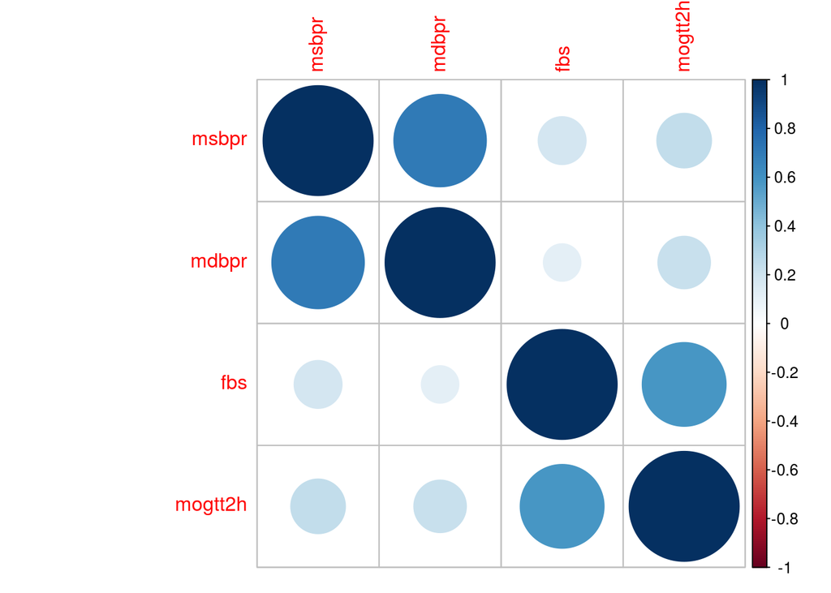

```r
corrplot(Cor_LogDS_BPSugar)
```

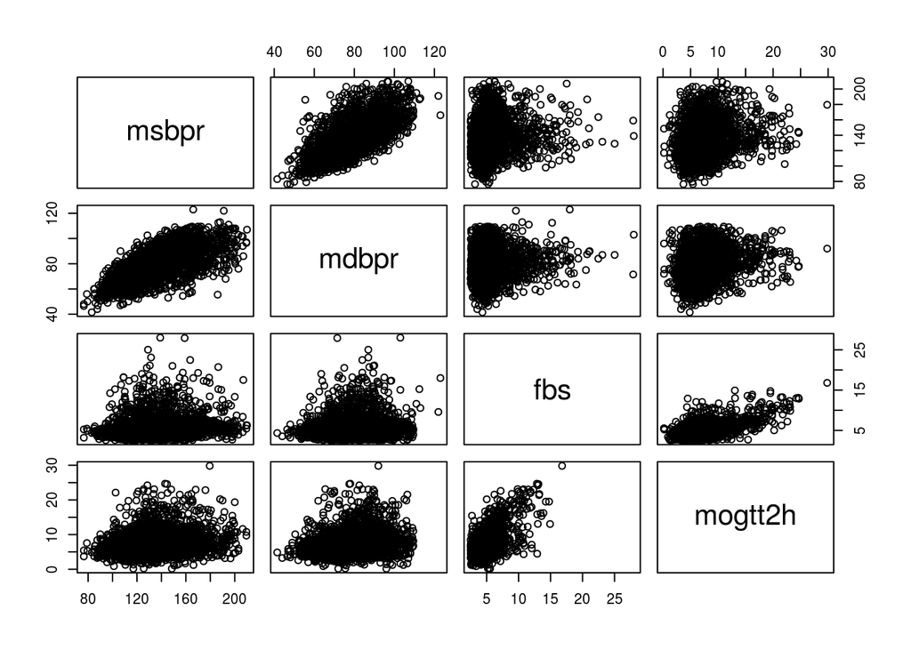

```r
pairs(LogDS_BPSugar)
```

### Model21 - age, msbp, fbs, hdl

```r
Model21 <- glm(dmdxcat ~ age + msbpr + fbs + hdl,
               family = binomial(link = "logit"),
               data = LogDS)
summary(Model21)
```

```
##
## Call:
## glm(formula = dmdxcat ~ age + msbpr + fbs + hdl, family = binomial(link = "logit"),
##     data = LogDS)
##
## Deviance Residuals:
##     Min       1Q   Median       3Q      Max
## -2.4471  -0.4072  -0.2674  -0.1545   3.2182
##
## Coefficients:
##              Estimate Std. Error z value Pr(>|z|)
## (Intercept) -7.663638   0.497228 -15.413  < 2e-16 ***
## age          0.055469   0.005431  10.214  < 2e-16 ***
## msbpr       -0.001279   0.002995  -0.427 0.669400
## fbs          0.603557   0.029528  20.440  < 2e-16 ***
## hdl         -0.705870   0.186668  -3.781 0.000156 ***
## ---
## Signif. codes:  0 '***' 0.001 '**' 0.01 '*' 0.05 '.' 0.1 ' ' 1
##
## (Dispersion parameter for binomial family taken to be 1)
##
##     Null deviance: 2785.0  on 3816  degrees of freedom
## Residual deviance: 1829.6  on 3812  degrees of freedom
##   (3 observations deleted due to missingness)
## AIC: 1839.6
##
## Number of Fisher Scoring iterations: 6
```

```r
kable(tidy(Model21))
```

| term | estimate | std.error | statistic | p.value |
| --- | --- | --- | --- | --- |
| (Intercept) | -7.6636378 | 0.4972279 | -15.4127279 | 0.0000000 |
| age | 0.0554692 | 0.0054306 | 10.2142573 | 0.0000000 |
| msbpr | -0.0012788 | 0.0029950 | -0.4269716 | 0.6694000 |
| fbs | 0.6035566 | 0.0295279 | 20.4401809 | 0.0000000 |
| hdl | -0.7058703 | 0.1866676 | -3.7814292 | 0.0001559 |

sbp not significant

### Model22 - age, dbp, fbs, hdl

```r
Model22 <- glm(dmdxcat ~ age + mdbpr + fbs + hdl,
               family = binomial(link = "logit"),
               data = LogDS)
summary(Model22)
```

```
##
## Call:
## glm(formula = dmdxcat ~ age + mdbpr + fbs + hdl, family = binomial(link = "logit"),
##     data = LogDS)
##
## Deviance Residuals:
##     Min       1Q   Median       3Q      Max
## -2.4274  -0.4061  -0.2645  -0.1506   3.2026
##
## Coefficients:
##              Estimate Std. Error z value Pr(>|z|)
## (Intercept) -8.619209   0.600377 -14.356  < 2e-16 ***
## age          0.053878   0.005010  10.755  < 2e-16 ***
## mdbpr        0.011081   0.005571   1.989 0.046703 *
## fbs          0.596706   0.029305  20.362  < 2e-16 ***
## hdl         -0.690474   0.187613  -3.680 0.000233 ***
## ---
## Signif. codes:  0 '***' 0.001 '**' 0.01 '*' 0.05 '.' 0.1 ' ' 1
##
## (Dispersion parameter for binomial family taken to be 1)
##
##     Null deviance: 2785.0  on 3816  degrees of freedom
## Residual deviance: 1825.8  on 3812  degrees of freedom
##   (3 observations deleted due to missingness)
## AIC: 1835.8
##
## Number of Fisher Scoring iterations: 6
```

```r
kable(tidy(Model22))
```

| term | estimate | std.error | statistic | p.value |
| --- | --- | --- | --- | --- |
| (Intercept) | -8.6192088 | 0.6003768 | -14.356332 | 0.0000000 |
| age | 0.0538784 | 0.0050098 | 10.754661 | 0.0000000 |
| mdbpr | 0.0110806 | 0.0055710 | 1.988982 | 0.0467032 |
| fbs | 0.5967062 | 0.0293053 | 20.361708 | 0.0000000 |
| hdl | -0.6904737 | 0.1876130 | -3.680309 | 0.0002330 |

dbp significant

### Model32 - age, dbp, fbs, hdl, mogtt

```r
Model32 <- glm(dmdxcat ~ age + mdbpr + fbs + hdl + mogtt2h,
               family = binomial(link = "logit"),
               data = LogDS)
summary(Model32)
```

```
##
## Call:
## glm(formula = dmdxcat ~ age + mdbpr + fbs + hdl + mogtt2h, family = binomial(link = "logit"),
##     data = LogDS)
##
## Deviance Residuals:
##     Min       1Q   Median       3Q      Max
## -0.6486  -0.1457  -0.1234  -0.1070   3.3437
##
## Coefficients:
##              Estimate Std. Error z value Pr(>|z|)
## (Intercept) -7.368847   1.474097  -4.999 5.77e-07 ***
## age          0.001666   0.012853   0.130  0.89685
## mdbpr        0.013174   0.015518   0.849  0.39591
## fbs          0.120251   0.107406   1.120  0.26289
## hdl         -0.070759   0.481250  -0.147  0.88311
## mogtt2h      0.135505   0.051215   2.646  0.00815 **
## ---
## Signif. codes:  0 '***' 0.001 '**' 0.01 '*' 0.05 '.' 0.1 ' ' 1
##
## (Dispersion parameter for binomial family taken to be 1)
##
##     Null deviance: 408.12  on 3399  degrees of freedom
## Residual deviance: 378.72  on 3394  degrees of freedom
##   (420 observations deleted due to missingness)
## AIC: 390.72
##
## Number of Fisher Scoring iterations: 7
```

```r
kable(tidy(Model32))
```

| term | estimate | std.error | statistic | p.value |
| --- | --- | --- | --- | --- |
| (Intercept) | -7.3688466 | 1.4740969 | -4.9988888 | 0.0000006 |
| age | 0.0016663 | 0.0128529 | 0.1296413 | 0.8968502 |
| mdbpr | 0.0131740 | 0.0155180 | 0.8489524 | 0.3959078 |
| fbs | 0.1202508 | 0.1074062 | 1.1195888 | 0.2628890 |
| hdl | -0.0707591 | 0.4812499 | -0.1470319 | 0.8831068 |
| mogtt2h | 0.1355051 | 0.0512154 | 2.6457907 | 0.0081500 |

mogtt as confounder?

#### Confounder fbs

Model22 - age, dbp, fbs, hdl

```r
Model22_01 <- tidy(Model22)
Model32_01 <- tidy(Model32)
((Model32_01[2,2] - Model22_01[2,2])/Model22_01[2,2])*100
```

```
##    estimate
## 1 -96.90735
```

#### Confounder mogtt

Model23 - age, dbp, mogtt, hdl

```r
Model23 <- glm(dmdxcat ~ age + mdbpr + mogtt2h + hdl,
               family = binomial(link = "logit"),
               data = LogDS)
Model23_01 <- tidy(Model23)
((Model32_01[2,2]-Model23_01[2,2])/Model23_01[2,2])*100
```

```
##   estimate
## 1 137.2233
```

mogtt has higher changes, thus mogtt selected as compared to fbs

### Model23 - age, dbp, mogtt, hdl

```r
summary(Model23)
```

```
##
## Call:
## glm(formula = dmdxcat ~ age + mdbpr + mogtt2h + hdl, family = binomial(link = "logit"),
##     data = LogDS)
##
## Deviance Residuals:
##     Min       1Q   Median       3Q      Max
## -0.5926  -0.1457  -0.1222  -0.1056   3.3340
##
## Coefficients:
##               Estimate Std. Error z value Pr(>|z|)
## (Intercept) -6.9682939  1.4141087  -4.928 8.32e-07 ***
## age          0.0007024  0.0128165   0.055    0.956
## mdbpr        0.0125339  0.0153684   0.816    0.415
## mogtt2h      0.1793428  0.0324848   5.521 3.37e-08 ***
## hdl         -0.0732444  0.4768473  -0.154    0.878
## ---
## Signif. codes:  0 '***' 0.001 '**' 0.01 '*' 0.05 '.' 0.1 ' ' 1
##
## (Dispersion parameter for binomial family taken to be 1)
##
##     Null deviance: 408.12  on 3399  degrees of freedom
## Residual deviance: 379.92  on 3395  degrees of freedom
##   (420 observations deleted due to missingness)
## AIC: 389.92
##
## Number of Fisher Scoring iterations: 7
```

```r
kable(tidy(Model23))
```

| term | estimate | std.error | statistic | p.value |
| --- | --- | --- | --- | --- |
| (Intercept) | -6.9682939 | 1.4141087 | -4.9276934 | 0.0000008 |
| age | 0.0007024 | 0.0128165 | 0.0548047 | 0.9562940 |
| mdbpr | 0.0125339 | 0.0153684 | 0.8155614 | 0.4147511 |
| mogtt2h | 0.1793428 | 0.0324848 | 5.5208219 | 0.0000000 |
| hdl | -0.0732444 | 0.4768473 | -0.1536014 | 0.8779240 |

### Explore Interaction

Preliminary Main Effect Model - Model41

- outcome: dm
- covariate: age, dbp, fbs, gender

Simple Logistic Regression for each covariates

```r
SLogR_Model41 <- LogDS %>%
  dplyr::select(age, mdbpr, fbs, gendercat) %>%
  purrr::map(~glm(dmdxcat ~ .x,
                  family = binomial,
                  data = LogDS)) %>%
  purrr::map(tidy) %>%  bind_rows()

ResultSLogRMod41 <- SLogR_Model41 %>%
  mutate(model = c("b0", "age",
                   "b0", "mdbpr",
                   "b0", "fbs",
                   "b0", "gendercat")) %>%
  dplyr::select(model, everything())
kable(ResultSLogRMod41)
```

| model | term | estimate | std.error | statistic | p.value |
| --- | --- | --- | --- | --- | --- |
| b0 | (Intercept) | -4.6428926 | 0.2196262 | -21.139979 | 0.0000000 |
| age | .x | 0.0511159 | 0.0038629 | 13.232369 | 0.0000000 |
| b0 | (Intercept) | -4.6032505 | 0.3579917 | -12.858541 | 0.0000000 |
| mdbpr | .x | 0.0327641 | 0.0043676 | 7.501674 | 0.0000000 |
| b0 | (Intercept) | -5.9050029 | 0.1967860 | -30.007224 | 0.0000000 |
| fbs | .x | 0.6167881 | 0.0287735 | 21.435952 | 0.0000000 |
| b0 | (Intercept) | -2.0771908 | 0.0636206 | -32.649639 | 0.0000000 |
| gendercat | .xmale | 0.2222904 | 0.1025100 | 2.168476 | 0.0301225 |

Multiple Logistic Regression

```r
Model41 <- glm(dmdxcat ~ age + mdbpr + fbs + gendercat,
               family = binomial(link = "logit"),
               data = LogDS)
summary(Model41)
```

```
##
## Call:
## glm(formula = dmdxcat ~ age + mdbpr + fbs + gendercat, family = binomial(link = "logit"),
##     data = LogDS)
##
## Deviance Residuals:
##     Min       1Q   Median       3Q      Max
## -2.3504  -0.4095  -0.2679  -0.1535   3.1943
##
## Coefficients:
##                Estimate Std. Error z value Pr(>|z|)
## (Intercept)   -9.511547   0.553597 -17.181   <2e-16 ***
## age            0.051388   0.004976  10.326   <2e-16 ***
## mdbpr          0.011534   0.005575   2.069   0.0385 *
## fbs            0.599771   0.029351  20.435   <2e-16 ***
## gendercatmale  0.124927   0.128424   0.973   0.3307
## ---
## Signif. codes:  0 '***' 0.001 '**' 0.01 '*' 0.05 '.' 0.1 ' ' 1
##
## (Dispersion parameter for binomial family taken to be 1)
##
##     Null deviance: 2785  on 3816  degrees of freedom
## Residual deviance: 1839  on 3812  degrees of freedom
##   (3 observations deleted due to missingness)
## AIC: 1849
##
## Number of Fisher Scoring iterations: 6
```

```r
kable(tidy(Model41))
```

| term | estimate | std.error | statistic | p.value |
| --- | --- | --- | --- | --- |
| (Intercept) | -9.5115475 | 0.5535974 | -17.1813455 | 0.0000000 |
| age | 0.0513880 | 0.0049764 | 10.3263273 | 0.0000000 |
| mdbpr | 0.0115341 | 0.0055746 | 2.0690408 | 0.0385423 |
| fbs | 0.5997708 | 0.0293506 | 20.4346895 | 0.0000000 |
| gendercatmale | 0.1249275 | 0.1284237 | 0.9727761 | 0.3306646 |

#### Interaction 1 - age:dbp

Interaction 1 - age:dbp

- covariate: age, dbp, fbs, gender, age:dbp

```r
Model41_Int01 <- glm(dmdxcat ~ age + mdbpr + fbs + gendercat + age:mdbpr,
                     family = binomial(link = "logit"),
                     data = LogDS)
summary(Model41_Int01)
```

```
##
## Call:
## glm(formula = dmdxcat ~ age + mdbpr + fbs + gendercat + age:mdbpr,
##     family = binomial(link = "logit"), data = LogDS)
##
## Deviance Residuals:
##     Min       1Q   Median       3Q      Max
## -2.3546  -0.4128  -0.2684  -0.1461   3.2630
##
## Coefficients:
##                 Estimate Std. Error z value Pr(>|z|)
## (Intercept)   -1.244e+01  2.040e+00  -6.096 1.09e-09 ***
## age            1.032e-01  3.492e-02   2.955  0.00313 **
## mdbpr          4.895e-02  2.554e-02   1.917  0.05526 .
## fbs            5.972e-01  2.937e-02  20.330  < 2e-16 ***
## gendercatmale  1.276e-01  1.283e-01   0.994  0.32005
## age:mdbpr     -6.584e-04  4.381e-04  -1.503  0.13290
## ---
## Signif. codes:  0 '***' 0.001 '**' 0.01 '*' 0.05 '.' 0.1 ' ' 1
##
## (Dispersion parameter for binomial family taken to be 1)
##
##     Null deviance: 2785.0  on 3816  degrees of freedom
## Residual deviance: 1836.7  on 3811  degrees of freedom
##   (3 observations deleted due to missingness)
## AIC: 1848.7
##
## Number of Fisher Scoring iterations: 6
```

```r
kable(tidy(Model41_Int01))
```

| term | estimate | std.error | statistic | p.value |
| --- | --- | --- | --- | --- |
| (Intercept) | -12.4373230 | 2.0403511 | -6.0956778 | 0.0000000 |
| age | 0.1031804 | 0.0349176 | 2.9549650 | 0.0031270 |
| mdbpr | 0.0489506 | 0.0255372 | 1.9168340 | 0.0552590 |
| fbs | 0.5971793 | 0.0293737 | 20.3304355 | 0.0000000 |
| gendercatmale | 0.1276150 | 0.1283404 | 0.9943474 | 0.3200537 |
| age:mdbpr | -0.0006584 | 0.0004381 | -1.5027573 | 0.1329016 |

interaction term not significant

#### Interaction 2 - age:fbs

- covariate: age, dbp, fbs, gender, age:fbs

```r
Model41_Int02 <- glm(dmdxcat ~ age + mdbpr + fbs + gendercat + age:fbs,
                     family = binomial(link = "logit"),
                     data = LogDS)
summary(Model41_Int02)
```

```
##
## Call:
## glm(formula = dmdxcat ~ age + mdbpr + fbs + gendercat + age:fbs,
##     family = binomial(link = "logit"), data = LogDS)
##
## Deviance Residuals:
##     Min       1Q   Median       3Q      Max
## -2.5360  -0.4041  -0.2701  -0.1645   3.1098
##
## Coefficients:
##                Estimate Std. Error z value Pr(>|z|)
## (Intercept)   -8.163191   0.945998  -8.629  < 2e-16 ***
## age            0.024719   0.016232   1.523  0.12780
## mdbpr          0.011818   0.005607   2.108  0.03505 *
## fbs            0.384076   0.127715   3.007  0.00264 **
## gendercatmale  0.126805   0.128989   0.983  0.32557
## age:fbs        0.004212   0.002454   1.716  0.08610 .
## ---
## Signif. codes:  0 '***' 0.001 '**' 0.01 '*' 0.05 '.' 0.1 ' ' 1
##
## (Dispersion parameter for binomial family taken to be 1)
##
##     Null deviance: 2785  on 3816  degrees of freedom
## Residual deviance: 1836  on 3811  degrees of freedom
##   (3 observations deleted due to missingness)
## AIC: 1848
##
## Number of Fisher Scoring iterations: 6
```

```r
kable(tidy(Model41_Int02))
```

| term | estimate | std.error | statistic | p.value |
| --- | --- | --- | --- | --- |
| (Intercept) | -8.1631911 | 0.9459984 | -8.6291806 | 0.0000000 |
| age | 0.0247191 | 0.0162323 | 1.5228274 | 0.1278019 |
| mdbpr | 0.0118180 | 0.0056069 | 2.1077419 | 0.0350533 |
| fbs | 0.3840762 | 0.1277148 | 3.0072953 | 0.0026358 |
| gendercatmale | 0.1268052 | 0.1289889 | 0.9830704 | 0.3255728 |
| age:fbs | 0.0042125 | 0.0024543 | 1.7163494 | 0.0860981 |

interaction term not significant

#### Interaction 3 - age:gender

- covariate: age, dbp, fbs, gender, age:gender

```r
Model41_Int03 <- glm(dmdxcat ~ age + mdbpr + fbs + gendercat + age:gendercat,
                     family = binomial(link = "logit"),
                     data = LogDS)
summary(Model41_Int03)
```

```
##
## Call:
## glm(formula = dmdxcat ~ age + mdbpr + fbs + gendercat + age:gendercat,
##     family = binomial(link = "logit"), data = LogDS)
##
## Deviance Residuals:
##     Min       1Q   Median       3Q      Max
## -2.3304  -0.4095  -0.2691  -0.1553   3.1646
##
## Coefficients:
##                    Estimate Std. Error z value Pr(>|z|)
## (Intercept)       -9.275552   0.590353 -15.712  < 2e-16 ***
## age                0.047064   0.006329   7.436 1.03e-13 ***
## mdbpr              0.011530   0.005575   2.068   0.0386 *
## fbs                0.600403   0.029394  20.426  < 2e-16 ***
## gendercatmale     -0.503082   0.593447  -0.848   0.3966
## age:gendercatmale  0.011055   0.010172   1.087   0.2771
## ---
## Signif. codes:  0 '***' 0.001 '**' 0.01 '*' 0.05 '.' 0.1 ' ' 1
##
## (Dispersion parameter for binomial family taken to be 1)
##
##     Null deviance: 2785.0  on 3816  degrees of freedom
## Residual deviance: 1837.8  on 3811  degrees of freedom
##   (3 observations deleted due to missingness)
## AIC: 1849.8
##
## Number of Fisher Scoring iterations: 6
```

```r
kable(tidy(Model41_Int03))
```

| term | estimate | std.error | statistic | p.value |
| --- | --- | --- | --- | --- |
| (Intercept) | -9.2755522 | 0.5903529 | -15.7118782 | 0.0000000 |
| age | 0.0470645 | 0.0063289 | 7.4364281 | 0.0000000 |
| mdbpr | 0.0115304 | 0.0055748 | 2.0683059 | 0.0386113 |
| fbs | 0.6004027 | 0.0293936 | 20.4263148 | 0.0000000 |
| gendercatmale | -0.5030816 | 0.5934467 | -0.8477284 | 0.3965893 |
| age:gendercatmale | 0.0110547 | 0.0101721 | 1.0867617 | 0.2771421 |

interaction term not significant

#### Interaction 4 - dbp:fbs

- covariate: age, dbp, fbs, gender, dbp:fbs

```r
Model41_Int04 <- glm(dmdxcat ~ age + mdbpr + fbs + gendercat + mdbpr:fbs,
                     family = binomial(link = "logit"),
                     data = LogDS)
summary(Model41_Int04)
```

```
##
## Call:
## glm(formula = dmdxcat ~ age + mdbpr + fbs + gendercat + mdbpr:fbs,
##     family = binomial(link = "logit"), data = LogDS)
##
## Deviance Residuals:
##     Min       1Q   Median       3Q      Max
## -2.3896  -0.4112  -0.2647  -0.1479   3.2540
##
## Coefficients:
##                 Estimate Std. Error z value Pr(>|z|)
## (Intercept)   -12.368721   1.477816  -8.370  < 2e-16 ***
## age             0.050971   0.005005  10.184  < 2e-16 ***
## mdbpr           0.046868   0.017622   2.660  0.00782 **
## fbs             1.042960   0.212973   4.897 9.72e-07 ***
## gendercatmale   0.124860   0.128408   0.972  0.33086
## mdbpr:fbs      -0.005422   0.002555  -2.122  0.03385 *
## ---
## Signif. codes:  0 '***' 0.001 '**' 0.01 '*' 0.05 '.' 0.1 ' ' 1
##
## (Dispersion parameter for binomial family taken to be 1)
##
##     Null deviance: 2785.0  on 3816  degrees of freedom
## Residual deviance: 1834.7  on 3811  degrees of freedom
##   (3 observations deleted due to missingness)
## AIC: 1846.7
##
## Number of Fisher Scoring iterations: 6
```

```r
kable(tidy(Model41_Int04))
```

| term | estimate | std.error | statistic | p.value |
| --- | --- | --- | --- | --- |
| (Intercept) | -12.3687211 | 1.4778161 | -8.3695942 | 0.0000000 |
| age | 0.0509707 | 0.0050051 | 10.1837891 | 0.0000000 |
| mdbpr | 0.0468675 | 0.0176223 | 2.6595618 | 0.0078242 |
| fbs | 1.0429603 | 0.2129725 | 4.8971584 | 0.0000010 |
| gendercatmale | 0.1248603 | 0.1284075 | 0.9723747 | 0.3308642 |
| mdbpr:fbs | -0.0054223 | 0.0025554 | -2.1218869 | 0.0338472 |

interaction term is significant

#### Interaction 5 - dbp:gender

- covariate: age, dbp, fbs, gender, dbp:gender

```r
Model41_Int05 <- glm(dmdxcat ~ age + mdbpr + fbs + gendercat + mdbpr:gendercat,
                     family = binomial(link = "logit"),
                     data = LogDS)
summary(Model41_Int05)
```

```
##
## Call:
## glm(formula = dmdxcat ~ age + mdbpr + fbs + gendercat + mdbpr:gendercat,
##     family = binomial(link = "logit"), data = LogDS)
##
## Deviance Residuals:
##     Min       1Q   Median       3Q      Max
## -2.3494  -0.4102  -0.2685  -0.1522   3.1988
##
## Coefficients:
##                      Estimate Std. Error z value Pr(>|z|)
## (Intercept)         -9.699005   0.673180 -14.408   <2e-16 ***
## age                  0.051396   0.004976  10.328   <2e-16 ***
## mdbpr                0.013884   0.007328   1.895   0.0582 .
## fbs                  0.599665   0.029369  20.418   <2e-16 ***
## gendercatmale        0.575005   0.919842   0.625   0.5319
## mdbpr:gendercatmale -0.005547   0.011230  -0.494   0.6214
## ---
## Signif. codes:  0 '***' 0.001 '**' 0.01 '*' 0.05 '.' 0.1 ' ' 1
##
## (Dispersion parameter for binomial family taken to be 1)
##
##     Null deviance: 2785.0  on 3816  degrees of freedom
## Residual deviance: 1838.8  on 3811  degrees of freedom
##   (3 observations deleted due to missingness)
## AIC: 1850.8
##
## Number of Fisher Scoring iterations: 6
```

```r
kable(tidy(Model41_Int05))
```

| term | estimate | std.error | statistic | p.value |
| --- | --- | --- | --- | --- |
| (Intercept) | -9.6990046 | 0.6731799 | -14.4077452 | 0.0000000 |
| age | 0.0513963 | 0.0049762 | 10.3283229 | 0.0000000 |
| mdbpr | 0.0138838 | 0.0073284 | 1.8945160 | 0.0581566 |
| fbs | 0.5996649 | 0.0293695 | 20.4179662 | 0.0000000 |
| gendercatmale | 0.5750053 | 0.9198417 | 0.6251133 | 0.5318967 |
| mdbpr:gendercatmale | -0.0055468 | 0.0112297 | -0.4939372 | 0.6213505 |

interaction is not significant

#### Interaction 6 - fbs:gender

- covariate: age, dbp, fbs, gender, fbs:gender

```r
Model41_Int06 <- glm(dmdxcat ~ age + mdbpr + fbs + gendercat + fbs:gendercat,
                     family = binomial(link = "logit"),
                     data = LogDS)
summary(Model41_Int06)
```

```
##
## Call:
## glm(formula = dmdxcat ~ age + mdbpr + fbs + gendercat + fbs:gendercat,
##     family = binomial(link = "logit"), data = LogDS)
##
## Deviance Residuals:
##     Min       1Q   Median       3Q      Max
## -2.3996  -0.4085  -0.2693  -0.1539   3.1604
##
## Coefficients:
##                    Estimate Std. Error z value Pr(>|z|)
## (Intercept)       -9.298615   0.566502 -16.414   <2e-16 ***
## age                0.051583   0.004995  10.326   <2e-16 ***
## mdbpr              0.011561   0.005595   2.066   0.0388 *
## fbs                0.565803   0.034819  16.250   <2e-16 ***
## gendercatmale     -0.562929   0.436238  -1.290   0.1969
## fbs:gendercatmale  0.104452   0.063241   1.652   0.0986 .
## ---
## Signif. codes:  0 '***' 0.001 '**' 0.01 '*' 0.05 '.' 0.1 ' ' 1
##
## (Dispersion parameter for binomial family taken to be 1)
##
##     Null deviance: 2785.0  on 3816  degrees of freedom
## Residual deviance: 1836.2  on 3811  degrees of freedom
##   (3 observations deleted due to missingness)
## AIC: 1848.2
##
## Number of Fisher Scoring iterations: 6
```

```r
kable(tidy(Model41_Int06))
```

| term | estimate | std.error | statistic | p.value |
| --- | --- | --- | --- | --- |
| (Intercept) | -9.2986148 | 0.5665017 | -16.414098 | 0.0000000 |
| age | 0.0515833 | 0.0049954 | 10.326244 | 0.0000000 |
| mdbpr | 0.0115613 | 0.0055951 | 2.066315 | 0.0387987 |
| fbs | 0.5658035 | 0.0348186 | 16.250025 | 0.0000000 |
| gendercatmale | -0.5629290 | 0.4362385 | -1.290416 | 0.1969064 |
| fbs:gendercatmale | 0.1044516 | 0.0632407 | 1.651651 | 0.0986057 |

no interaction

### Prelim Final Model

Preliminary Final Model

```r
PrelimFinalModel <- glm(dmdxcat ~ age + mdbpr + totchol + gendercat + mdbpr:totchol,
                        family = binomial(link = "logit"),
                        data = LogDS)
summary(PrelimFinalModel)
```

```
##
## Call:
## glm(formula = dmdxcat ~ age + mdbpr + totchol + gendercat + mdbpr:totchol,
##     family = binomial(link = "logit"), data = LogDS)
##
## Deviance Residuals:
##     Min       1Q   Median       3Q      Max
## -1.2754  -0.5548  -0.4105  -0.2805   2.7467
##
## Coefficients:
##                Estimate Std. Error z value Pr(>|z|)
## (Intercept)   -8.358601   1.858872  -4.497  6.9e-06 ***
## age            0.049031   0.004042  12.130  < 2e-16 ***
## mdbpr          0.049270   0.022931   2.149   0.0317 *
## totchol        0.320980   0.308882   1.039   0.2987
## gendercatmale  0.085192   0.106921   0.797   0.4256
## mdbpr:totchol -0.004309   0.003786  -1.138   0.2551
## ---
## Signif. codes:  0 '***' 0.001 '**' 0.01 '*' 0.05 '.' 0.1 ' ' 1
##
## (Dispersion parameter for binomial family taken to be 1)
##
##     Null deviance: 2797.7  on 3819  degrees of freedom
## Residual deviance: 2571.9  on 3814  degrees of freedom
## AIC: 2583.9
##
## Number of Fisher Scoring iterations: 5
```

```r
kable(tidy(PrelimFinalModel))
```

| term | estimate | std.error | statistic | p.value |
| --- | --- | --- | --- | --- |
| (Intercept) | -8.3586012 | 1.8588715 | -4.4965997 | 0.0000069 |
| age | 0.0490312 | 0.0040420 | 12.1304647 | 0.0000000 |
| mdbpr | 0.0492696 | 0.0229306 | 2.1486429 | 0.0316627 |
| totchol | 0.3209801 | 0.3088821 | 1.0391668 | 0.2987272 |
| gendercatmale | 0.0851921 | 0.1069211 | 0.7967752 | 0.4255816 |
| mdbpr:totchol | -0.0043085 | 0.0037858 | -1.1380609 | 0.2550951 |

Model matrix for PrelimFinalModel

```r
kable(head(model.matrix(PrelimFinalModel)))
```

| (Intercept) | age | mdbpr | totchol | gendercatmale | mdbpr:totchol |
| --- | --- | --- | --- | --- | --- |
| 1 | 70 | 80.0 | 5.43 | 0 | 434.400 |
| 1 | 20 | 58.0 | 5.13 | 1 | 297.540 |
| 1 | 29 | 60.0 | 5.55 | 0 | 333.000 |
| 1 | 25 | 68.5 | 4.01 | 1 | 274.685 |
| 1 | 37 | 78.0 | 5.21 | 0 | 406.380 |
| 1 | 43 | 65.5 | 6.19 | 0 | 405.445 |

#### Predicted value - raw predicted (logit)

Raw Predicted Values (logit) = a+bx

```r
logitPredProb_PrelimModel <- predict(PrelimFinalModel, type="link")
kable(head(logitPredProb_PrelimModel))
```

| x |
| --- |
| -1.113541 |
| -4.070473 |
| -3.633813 |
| -3.569013 |
| -2.780002 |
| -2.783096 |

```r
PredProb_PrelimModel <- fitted(PrelimFinalModel)
kable(head(PredProb_PrelimModel))
```

| x |
| --- |
| 0.2472113 |
| 0.0167828 |
| 0.0257355 |
| 0.0274111 |
| 0.0584145 |
| 0.0582445 |

alternatively

```r
PredProbAlt_PrelimModel <- predict(PrelimFinalModel, type = "response")
kable(head(PredProbAlt_PrelimModel))
```

| x |
| --- |
| 0.2472113 |
| 0.0167828 |
| 0.0257355 |
| 0.0274111 |
| 0.0584145 |
| 0.0582445 |

#### Residual - raw

raw residual

```r
kable(head(augment(PrelimFinalModel)))
```

| dmdxcat | age | mdbpr | totchol | gendercat | .fitted | .se.fit | .resid | .hat | .sigma | .cooksd | .std.resid |
| --- | --- | --- | --- | --- | --- | --- | --- | --- | --- | --- | --- |
| no | 70 | 80.0 | 5.43 | female | -1.113541 | 0.0963024 | -0.7536188 | 0.0017259 | 0.8211918 | 9.48e-05 | -0.7542700 |
| no | 20 | 58.0 | 5.13 | male | -4.070473 | 0.2046208 | -0.1839852 | 0.0006910 | 0.8212773 | 2.00e-06 | -0.1840488 |
| no | 29 | 60.0 | 5.55 | female | -3.633813 | 0.1495047 | -0.2283524 | 0.0005605 | 0.8212743 | 2.50e-06 | -0.2284164 |
| no | 25 | 68.5 | 4.01 | male | -3.569013 | 0.1875348 | -0.2357703 | 0.0009378 | 0.8212738 | 4.40e-06 | -0.2358809 |
| no | 37 | 78.0 | 5.21 | female | -2.780002 | 0.0975610 | -0.3469584 | 0.0005236 | 0.8212634 | 5.40e-06 | -0.3470493 |
| no | 43 | 65.5 | 6.19 | female | -2.783096 | 0.1069932 | -0.3464379 | 0.0006280 | 0.8212635 | 6.50e-06 | -0.3465468 |

```r
kable(head(augment(PrelimFinalModel,
                   type.predict="response",
                   type.residual="respone")))
```

| dmdxcat | age | mdbpr | totchol | gendercat | .fitted | .se.fit | .hat | .sigma | .cooksd | .std.resid |
| --- | --- | --- | --- | --- | --- | --- | --- | --- | --- | --- |
| no | 70 | 80.0 | 5.43 | female | 0.2472113 | 0.0179217 | 0.0017259 | 0.8211918 | 9.48e-05 | -0.7542700 |
| no | 20 | 58.0 | 5.13 | male | 0.0167828 | 0.0033765 | 0.0006910 | 0.8212773 | 2.00e-06 | -0.1840488 |
| no | 29 | 60.0 | 5.55 | female | 0.0257355 | 0.0037486 | 0.0005605 | 0.8212743 | 2.50e-06 | -0.2284164 |
| no | 25 | 68.5 | 4.01 | male | 0.0274111 | 0.0049996 | 0.0009378 | 0.8212738 | 4.40e-06 | -0.2358809 |
| no | 37 | 78.0 | 5.21 | female | 0.0584145 | 0.0053661 | 0.0005236 | 0.8212634 | 5.40e-06 | -0.3470493 |
| no | 43 | 65.5 | 6.19 | female | 0.0582445 | 0.0058688 | 0.0006280 | 0.8212635 | 6.50e-06 | -0.3465468 |

## Model Checking

### Hosmer Lemeshow Test

```r
logitgof(LogDS$dmdx, fitted(PrelimFinalModel), g = 10)
```

```
##
##  Hosmer and Lemeshow test (binary model)
##
## data:  LogDS$dmdx, fitted(PrelimFinalModel)
## X-squared = 27.178, df = 8, p-value = 0.0006585
```

```r
hoslem.test(LogDS$dmdxcat, fitted(PrelimFinalModel), g = 10)
```

```
##
##  Hosmer and Lemeshow goodness of fit (GOF) test
##
## data:  LogDS$dmdxcat, fitted(PrelimFinalModel)
## X-squared = 3820, df = 8, p-value < 2.2e-16
```

```r
HLT_PrelimModel <- dx(PrelimFinalModel, byCov = T)
kable(tail(HLT_PrelimModel))
```

| (Intercept) | age | mdbpr | totchol | gendercatmale | mdbpr:totchol | y | P | n | yhat | Pr | dr | h | sPr | sdr | dChisq | dDev | dBhat |
| --- | --- | --- | --- | --- | --- | --- | --- | --- | --- | --- | --- | --- | --- | --- | --- | --- | --- |
| 1 | 67 | 74.0 | 10.51 | 0 | 777.74 | 1 | 0.1970309 | 1 | 0.1970309 | 2.018749 | 1.802440 | 0.0091573 | 2.028056 | 1.810750 | 4.113011 | 3.278815 | 0.0380123 |
| 1 | 38 | 94.5 | 8.70 | 1 | 822.15 | 1 | 0.0755813 | 1 | 0.0755813 | 3.497254 | 2.272684 | 0.0036611 | 3.503674 | 2.276856 | 12.275732 | 5.184073 | 0.0451075 |
| 1 | 61 | 64.0 | 10.14 | 1 | 648.96 | 1 | 0.1583495 | 1 | 0.1583495 | 2.305460 | 1.919870 | 0.0162039 | 2.324369 | 1.935617 | 5.402691 | 3.746612 | 0.0889868 |
| 1 | 40 | 98.0 | 9.87 | 0 | 967.26 | 1 | 0.0712065 | 1 | 0.0712065 | 3.611602 | 2.298770 | 0.0071140 | 3.624517 | 2.306991 | 13.137127 | 5.322205 | 0.0941268 |
| 1 | 61 | 100.0 | 10.21 | 1 | 1021.00 | 1 | 0.1858322 | 1 | 0.1858322 | 2.093131 | 1.834618 | 0.0213971 | 2.115890 | 1.854566 | 4.476992 | 3.439415 | 0.0978893 |
| 1 | 66 | 72.0 | 14.91 | 0 | 1073.52 | 1 | 0.1955121 | 1 | 0.1955121 | 2.028490 | 1.806728 | 0.0383486 | 2.068541 | 1.842400 | 4.278860 | 3.394438 | 0.1706318 |

### Diagnostic Plot

```r
PrelimFinalModel
```

```
##
## Call:  glm(formula = dmdxcat ~ age + mdbpr + totchol + gendercat + mdbpr:totchol,
##     family = binomial(link = "logit"), data = LogDS)
##
## Coefficients:
##   (Intercept)            age          mdbpr        totchol  gendercatmale
##     -8.358601       0.049031       0.049270       0.320980       0.085192
## mdbpr:totchol
##     -0.004309
##
## Degrees of Freedom: 3819 Total (i.e. Null);  3814 Residual
## Null Deviance:       2798
## Residual Deviance: 2572  AIC: 2584
```

```r
plot(PrelimFinalModel)
```

[output not shown]

### ROC Curve

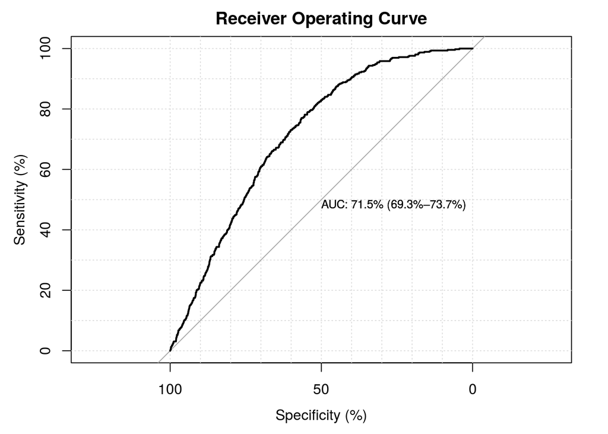

```r
gof_PrelimModel <- gof(PrelimFinalModel, plotROC = T)
```

```r
gof_PrelimModel
```

```
##       chiSq   df    pVal
## PrI  3521.4 3814 0.99970
## drI  2571.9 3814 1.00000
## PrG  3518.7 3809 0.99967
## drG  2569.1 3809 1.00000
## PrCT 3518.7 3809 0.99967
## drCT 2569.1 3809 1.00000
##                       val df       pVal
## HL chiSq         27.17800  8 0.00065854 ***
## mHL F             1.90380  9 0.04700500 *
## OsRo Z                 NA NA 1.4499e-05 ***
## SstPgeq0.5 Z      0.63617 NA 0.52466000
## SstPl0.5 Z        5.33310 NA 9.6569e-08 ***
## SstBoth chiSq    28.84600  2 5.4464e-07 ***
## SllPgeq0.5 chiSq  0.40879  1 0.52258000
## SllPl0.5 chiSq   33.74200  1 6.2931e-09 ***
## SllBoth chiSq    34.03600  2 4.0658e-08 ***
## ---
## Signif. codes:  0 '***' 0.001 '**' 0.01 '*' 0.05 '.' 0.1 ' ' 1
```

```r
gof_PrelimModel$auc
```

```
##          auc lower 95% CI upper 95% CI
##     71.49951     69.32723     73.67179
## attr(,"interpret")
## [1] "auc = 0.5       --> useless"   "0.7 < auc < 0.8 --> good"
## [3] "0.8 < auc < 0.9 --> excellent"
```

#### Chisquare for Goodness of fitness

```r
kable(gof_PrelimModel$chiSq)
```

| test | chiSq | df | pVal |
| --- | --- | --- | --- |
| PrI | 3521.406 | 3814 | 0.9997006 |
| drI | 2571.888 | 3814 | 1.0000000 |
| PrG | 3518.700 | 3809 | 0.9996714 |
| drG | 2569.116 | 3809 | 1.0000000 |
| PrCT | 3518.700 | 3809 | 0.9996714 |
| drCT | 2569.116 | 3809 | 1.0000000 |

#### Hosmer Lemeshow Test Contingency Table

```r
kable(gof_PrelimModel$ctHL)
```

| P | y1 | y1hat | y0 | y0hat | n | Pbar |
| --- | --- | --- | --- | --- | --- | --- |
| 0.0321 | 3 | 9.175063 | 379 | 372.8249 | 382 | 0.0240185 |
| 0.0498 | 10 | 15.843318 | 372 | 366.1567 | 382 | 0.0414747 |
| 0.0658 | 13 | 22.057538 | 369 | 359.9425 | 382 | 0.0577422 |
| 0.0817 | 27 | 28.253139 | 355 | 353.7469 | 382 | 0.0739611 |
| 0.1 | 42 | 34.623350 | 340 | 347.3766 | 382 | 0.0906370 |
| 0.122 | 50 | 42.400810 | 332 | 339.5992 | 382 | 0.1109969 |
| 0.148 | 65 | 51.390431 | 317 | 330.6096 | 382 | 0.1345299 |
| 0.182 | 74 | 62.610250 | 308 | 319.3897 | 382 | 0.1639012 |
| 0.232 | 83 | 78.140088 | 299 | 303.8599 | 382 | 0.2045552 |
| 0.557 | 90 | 112.506013 | 292 | 269.4940 | 382 | 0.2945184 |

summary of GOF tests

```r
kable(gof_PrelimModel$gof)
```

| test | stat | val | df | pVal |
| --- | --- | --- | --- | --- |
| HL | chiSq | 27.1784007 | 8 | 0.0006585 |
| mHL | F | 1.9037569 | 9 | 0.0470048 |
| OsRo | Z | -4.3361680 | NA | 0.0000145 |
| SstPgeq0.5 | Z | 0.6361724 | NA | 0.5246641 |
| SstPl0.5 | Z | 5.3330638 | NA | 0.0000001 |
| SstBoth | chiSq | 28.8462852 | 2 | 0.0000005 |
| SllPgeq0.5 | chiSq | 0.4087919 | 1 | 0.5225833 |
| SllPl0.5 | chiSq | 33.7418981 | 1 | 0.0000000 |
| SllBoth | chiSq | 34.0361547 | 2 | 0.0000000 |